# Pump it Up: Data Mining the Water Table challenge (Top 4%)

Pau Roger Puig-Sureda

# Import Libraries

```r
library(ggplot2)
library(knitr)
library(dplyr)
library(plyr)
library(corrplot)
library(rpart)
library(data.table)
```

# Introduction

**Pump it Up: Data Mining the Water Table challenge** hosted by DrivenData, a platform for real world data challenges where data science can have positive social impact. For more information, please refer: https://www.drivendata.org/

# Goal

The participants need to predict which water pumps are functional, which need to be repaired and which do not work at all among those included in the dataset. To that end, the dataset provides a set of information about the water pumps (provided by [Taarifa](http://taarifa.org/) and the [Tanzanian Ministry of Water](http://maji.go.tz/)), information valuable to predict their operating condition.

# Data Loading

Load the datasets and visualize their values to find possible missing values, mistakes in the data or aspect to focus when cleaning the dataset.

```r
colClasses = c("integer","numeric","Date","factor","numeric","factor",
               "numeric","numeric","factor","integer","factor","factor",
               "factor","factor","factor","factor","factor","numeric",
               "logical","factor","factor","factor","logical","integer",
               "factor","factor","factor","factor","factor","factor",
               "factor","factor","factor","factor","factor","factor",
               "factor","factor","factor","factor")

training_set = read.csv(file = "datasets/Training_set_values.csv", header = TRUE, sep = ",", colClasses = colClasses)
training_labels = read.csv("datasets/Training_set_labels.csv", header = TRUE, sep = ",",  colClasses = c("integer","factor"))
test_set = read.csv("datasets/Test_set_values.csv", header = TRUE, sep = ",", colClasses = colClasses)

# summary of the three datasets.
summary(training_labels)
```

```
##        id                         status_group
##  Min.   :    0   functional             :32259
##  1st Qu.:18520   functional needs repair: 4317
##  Median :37062   non functional         :22824
##  Mean   :37115
##  3rd Qu.:55657
##  Max.   :74247
```

```r
summary(training_set)
```

```
##        id          amount_tsh       date_recorded
##  Min.   :    0   Min.   :     0.0   Min.   :2002-10-14
##  1st Qu.:18520   1st Qu.:     0.0   1st Qu.:2011-04-01
##  Median :37062   Median :     0.0   Median :2012-10-10
##  Mean   :37115   Mean   :   317.7   Mean   :2012-03-29
##  3rd Qu.:55657   3rd Qu.:    20.0   3rd Qu.:2013-02-09
##  Max.   :74247   Max.   :350000.0   Max.   :2013-12-03
##
##                     funder        gps_height          installer
##  Government Of Tanzania: 9084   Min.   : -90.0   DWE       :17402
##                        : 3635   1st Qu.:   0.0             : 3655
##  Danida                : 3114   Median : 369.0   Government: 1825
##  Hesawa                : 2202   Mean   : 668.3   RWE       : 1206
##  Rwssp                 : 1374   3rd Qu.:1319.2   Commu     : 1060
##  World Bank            : 1349   Max.   :2770.0   DANIDA    : 1050
##  (Other)               :38642                    (Other)   :33202
##    longitude        latitude            wpt_name      num_private
##  Min.   : 0.00   Min.   :-11.649   none     : 3563   Min.   :   0.0000
##  1st Qu.:33.09   1st Qu.: -8.541   Shuleni  : 1748   1st Qu.:   0.0000
##  Median :34.91   Median : -5.022   Zahanati :  830   Median :   0.0000
##  Mean   :34.08   Mean   : -5.706   Msikitini:  535   Mean   :   0.4741
##  3rd Qu.:37.18   3rd Qu.: -3.326   Kanisani :  323   3rd Qu.:   0.0000
##  Max.   :40.35   Max.   :  0.000   Bombani  :  271   Max.   :1776.0000
##                                    (Other)  :52130
##              basin          subvillage            region
##  Lake Victoria  :10248   Madukani:  508   Iringa     : 5294
##  Pangani        : 8940   Shuleni :  506   Shinyanga  : 4982
##  Rufiji         : 7976   Majengo :  502   Mbeya      : 4639
##  Internal       : 7785   Kati    :  373   Kilimanjaro: 4379
##  Lake Tanganyika: 6432           :  371   Morogoro   : 4006
##  Wami / Ruvu    : 5987   Mtakuja :  262   Arusha     : 3350
##  (Other)        :12032   (Other) :56878   (Other)    :32750
##   region_code    district_code             lga               ward
##  11     : 5300   1      :12203   Njombe      : 2503   Igosi    :  307
##  17     : 5011   2      :11173   Arusha Rural: 1252   Imalinyi :  252
##  12     : 4639   3      : 9998   Moshi Rural : 1251   Siha Kati:  232
##  3      : 4379   4      : 8999   Bariadi     : 1177   Mdandu   :  231
##  5      : 4040   5      : 4356   Rungwe      : 1106   Nduruma  :  217
##  18     : 3324   6      : 4074   Kilosa      : 1094   Kitunda  :  203
##  (Other):32707   (Other): 8597   (Other)     :51017   (Other)  :57958
```

[output cut: 57 more lines]

```
##  groundwater:45794   cattle trough              :  116
##  surface    :13328   communal standpipe         :28522
##  unknown    :  278   communal standpipe multiple: 6103
##                      dam                        :    7
##                      hand pump                  :17488
##                      improved spring            :  784
##                      other                      : 6380
##         waterpoint_type_group
##  cattle trough     :  116
##  communal standpipe:34625
##  dam               :    7
##  hand pump         :17488
##  improved spring   :  784
##  other             : 6380
##
```

```r
summary(test_set)
```

```
##        id          amount_tsh       date_recorded
##  Min.   :   10   Min.   :     0.0   Min.   :2001-03-26
##  1st Qu.:18727   1st Qu.:     0.0   1st Qu.:2011-03-31
##  Median :37362   Median :     0.0   Median :2012-10-07
##  Mean   :37162   Mean   :   322.8   Mean   :2012-03-24
##  3rd Qu.:55800   3rd Qu.:    25.0   3rd Qu.:2013-02-08
##  Max.   :74249   Max.   :200000.0   Max.   :2013-12-03
##
##                     funder       gps_height          installer
##  Government Of Tanzania:2215   Min.   : -57.0   DWE       :4349
##                        : 869   1st Qu.:   0.0             : 877
##  Danida                : 793   Median : 344.0   Government: 457
##  Hesawa                : 580   Mean   : 655.1   RWE       : 292
##  World Bank            : 352   3rd Qu.:1308.0   Commu     : 287
##  Kkkt                  : 336   Max.   :2777.0   DANIDA    : 255
##  (Other)               :9705                    (Other)   :8333
##    longitude        latitude            wpt_name      num_private
##  Min.   : 0.00   Min.   :-11.565   none     :  877   Min.   :  0.0000
##  1st Qu.:33.07   1st Qu.: -8.444   Shuleni  :  435   1st Qu.:  0.0000
##  Median :34.90   Median : -5.050   Zahanati :  204   Median :  0.0000
##  Mean   :34.06   Mean   : -5.685   Msikitini:  112   Mean   :  0.4151
##  3rd Qu.:37.20   3rd Qu.: -3.321   Sokoni   :   68   3rd Qu.:  0.0000
##  Max.   :40.33   Max.   :  0.000   Kanisani :   67   Max.   :669.0000
##                                    (Other)  :13087
##              basin         subvillage            region      region_code
##  Lake Victoria  :2623   Shuleni :  140   Shinyanga  :1311   17     :1323
##  Pangani        :2203   Majengo :  129   Iringa     :1305   11     :1308
##  Rufiji         :2011   Madukani:  121   Mbeya      :1119   12     :1120
##  Internal       :1857           :   99   Kilimanjaro:1115   3      :1115
##  Lake Tanganyika:1620   Kati    :   94   Morogoro   :1032   5      :1039
##  Wami / Ruvu    :1590   Sokoni  :   62   Kagera     : 858   18     : 859
##  (Other)        :2946   (Other) :14205   (Other)    :8110   (Other):8086
##  district_code           lga               ward         population
##  1      :3096   Njombe     :  625   Igosi    :   79   Min.   :    0.0
##  2      :2756   Moshi Rural:  315   Imalinyi :   66   1st Qu.:    0.0
##  3      :2523   Bariadi    :  308   Siha Kati:   65   Median :   20.0
##  4      :2254   Kasulu     :  275   Mdandu   :   61   Mean   :  184.1
##  5      :1072   Rungwe     :  275   Kitunda  :   57   3rd Qu.:  220.0
##  6      :1034   Kilosa     :  274   Chanika  :   50   Max.   :11469.0
##  (Other):2115   (Other)    :12778   (Other)  :14472
```

[output cut: 49 more lines]

```
##  borehole            :2981   groundwater:11492
##  dam                 : 184   surface    : 3289
##  other               :  69   unknown    :   69
##  rainwater harvesting: 568
##  river/lake          :2537
##  shallow well        :4316
##  spring              :4195
##                     waterpoint_type        waterpoint_type_group
##  cattle trough              :  34   cattle trough     :  34
##  communal standpipe         :7106   communal standpipe:8614
##  communal standpipe multiple:1508   dam               :   1
##  dam                        :   1   hand pump         :4396
##  hand pump                  :4396   improved spring   : 175
##  improved spring            : 175   other             :1630
##  other                      :1630
```

# Dataset Cleaning

Based on some problems detected in the visualization of the dataset, this step focuses on cleaning the data to facilitate their later exploration and the feature engineering process, thus improving the predictive models performance.

First of all, we are going to check the columns in the dataset with `NA's`.

```r
sapply(training_set, function(x) sum(is.na(x)))
```

```
##                    id            amount_tsh         date_recorded
##                     0                     0                     0
##                funder            gps_height             installer
##                     0                     0                     0
##             longitude              latitude              wpt_name
##                     0                     0                     0
##           num_private                 basin            subvillage
##                     0                     0                     0
##                region           region_code         district_code
##                     0                     0                     0
##                   lga                  ward            population
##                     0                     0                     0
##        public_meeting           recorded_by     scheme_management
##                  3334                     0                     0
##           scheme_name                permit     construction_year
##                     0                  3056                     0
##       extraction_type extraction_type_group extraction_type_class
##                     0                     0                     0
##            management      management_group               payment
##                     0                     0                     0
##          payment_type         water_quality         quality_group
##                     0                     0                     0
##              quantity        quantity_group                source
##                     0                     0                     0
##           source_type          source_class       waterpoint_type
##                     0                     0                     0
## waterpoint_type_group
##                     0
```

As seen in the previous figure, only `permit` and `public_meeting` have `NAs`. As they are logical features (TRUE or FALSE), we are going to transform them into a factor and replace the NA values by unknown.

```r
training_set$permit<- as.character(training_set$permit)
training_set$permit[is.na(training_set$permit)]<-"unknown"
training_set$permit<-as.factor(training_set$permit)

test_set$permit<- as.character(test_set$permit)
test_set$permit[is.na(test_set$permit)]<-"unknown"
test_set$permit<-as.factor(test_set$permit)

training_set$public_meeting<- as.character(training_set$public_meeting)
training_set$public_meeting[is.na(training_set$public_meeting)]<-"unknown"
training_set$public_meeting<-as.factor(training_set$public_meeting)

test_set$public_meeting<- as.character(test_set$public_meeting)
test_set$public_meeting[is.na(test_set$public_meeting)]<-"unknown"
test_set$public_meeting<-as.factor(test_set$public_meeting)
```

We check that the NA values have been replaced.

```r
sapply(training_set, function(x) sum(is.na(x)))
```

```
##                    id            amount_tsh         date_recorded
##                     0                     0                     0
##                funder            gps_height             installer
##                     0                     0                     0
##             longitude              latitude              wpt_name
##                     0                     0                     0
##           num_private                 basin            subvillage
##                     0                     0                     0
##                region           region_code         district_code
##                     0                     0                     0
##                   lga                  ward            population
##                     0                     0                     0
##        public_meeting           recorded_by     scheme_management
##                     0                     0                     0
##           scheme_name                permit     construction_year
##                     0                     0                     0
##       extraction_type extraction_type_group extraction_type_class
##                     0                     0                     0
##            management      management_group               payment
##                     0                     0                     0
##          payment_type         water_quality         quality_group
##                     0                     0                     0
##              quantity        quantity_group                source
##                     0                     0                     0
##           source_type          source_class       waterpoint_type
##                     0                     0                     0
## waterpoint_type_group
##                     0
```

```r
heightFit <- rpart(gps_height ~ latitude + longitude, data=training_set[(training_set$gps_height!=0),], method="anova")
training_set$gps_height[is.na(training_set$gps_height)] <- predict(heightFit, training_set[is.na(training_set$gps_height),])

heightFit <- rpart(gps_height ~ latitude + longitude, data=test_set[(test_set$gps_height!=0),], method="anova")
test_set$gps_height[is.na(test_set$gps_height)] <- predict(heightFit, test_set[is.na(test_set$gps_height),])
```

Next, `construction_year` includes values equal to 0 when it shouldn’t. It appears that missing values or erroneous measurements have been corrected by setting 0 as value. Consequently, we mutate these 0 values to `NA's`, avoiding in this way their influence in later calculations.

```r
# Training set
training_set <- mutate(training_set, construction_year = ifelse(construction_year == 0, NA, construction_year))

# Test set
test_set <- mutate(test_set, construction_year = ifelse(construction_year == 0, NA, construction_year))
```

Also, `population` has many values equal to zero, which appear to be missing values. To impute them, we are going to use the mean of the population.

```r
training_set$population[training_set$population==0]<- round(mean(training_set$population[training_set$population!=0]),digits = 0)
test_set$population[test_set$population==0]<- round(mean(test_set$population[test_set$population!=0]),digits = 0)
```

The `longitude` of Tanzania goes from 29 to 40. So 0 is equivalent to an NA as the next scatter plot suggests.

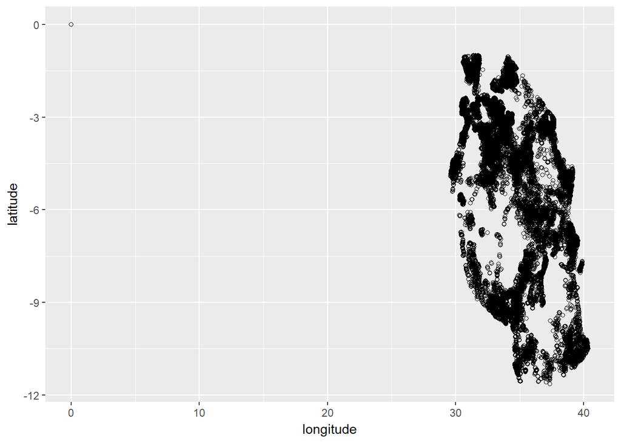

```r
ggplot(training_set, aes(x = longitude, y = latitude)) + geom_point(shape = 1)
```

To impute them, we are going to use the mean of the `latitude` and `longitude` of the other waterpoints in the same region.

```r
# Impute training longitude
longsummary <- aggregate(longitude~region,data=training_set[(training_set$longitude!=0),], FUN=mean)
longsummary$region <- as.character(longsummary$region)
for(i in 1:nrow(training_set)){
  row <- training_set[i,]
  if(row$longitude < 10){
    new_longitude <- longsummary[longsummary$region == row$region,]$longitude
    training_set[i,]$longitude <- new_longitude
  }
}

# Impute test longitude
longsummary <- aggregate(longitude~region,data=test_set[(test_set$longitude!=0),], FUN=mean)
longsummary$region <- as.character(longsummary$region)
for(i in 1:nrow(test_set)){
  row <- test_set[i,]
  if(row$longitude< 10){
    new_longitude <- longsummary[longsummary$region == row$region,]$longitude
    test_set[i,]$longitude <- new_longitude
  }
}

# Impute train latitude
latsummary <- aggregate(latitude~region,data=training_set[(training_set$latitude!=0),], FUN=mean)
latsummary$region <- as.character(latsummary$region)
for(i in 1:nrow(training_set)){
  row <- training_set[i,]
  if(row$latitude > -1e-06){
    new_latitude <- latsummary[latsummary$region == row$region,]$latitude
    training_set[i,]$latitude <- new_latitude
  }

}

# Impute test latitude
latsummary <- aggregate(latitude~region,data=test_set[(test_set$latitude!=0),], FUN=mean)
latsummary$region <- as.character(latsummary$region)
for(i in 1:nrow(test_set)){
  row <- test_set[i,]
  if(row$latitude > -1e-06){
    new_latitude <- latsummary[latsummary$region == row$region,]$latitude
    test_set[i,]$latitude <- new_latitude
  }

}
```

Let’s visualize if we have corrected the location errors.

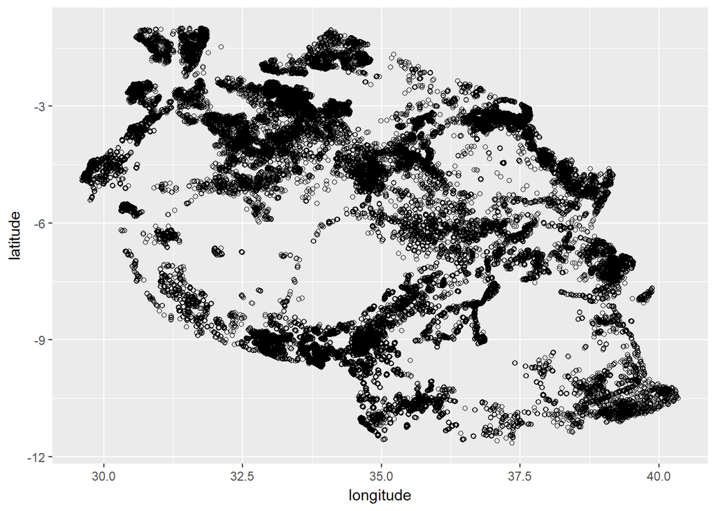

```r
ggplot(training_set, aes(x = longitude, y = latitude)) + geom_point(shape = 1)
```

Nice!

Some variables are not relevant for the prediction:

- `amount_tsh` has 70% of missing values.
- `num_private` is composed mostly of zeros.
- `wpt_name` refers to the name of the water point, which seems irrelevant to the prediction of its status.
- `scheme_name` includes the name of the waterpoint operator. `scheme_management` includes the same information but grouped by type, which seems more relevant to predict the status.

```r
training_set <- training_set[, -which(names(training_set) == "amount_tsh")]
training_set <- training_set[, -which(names(training_set) == "num_private")]
training_set <- training_set[, -which(names(training_set) == "wpt_name")]
training_set <- training_set[, -which(names(training_set) == "scheme_name")]

test_set <- test_set[, -which(names(test_set) == "amount_tsh")]
test_set <- test_set[, -which(names(test_set) == "num_private")]
test_set <- test_set[, -which(names(test_set) == "wpt_name")]
test_set <- test_set[, -which(names(test_set) == "scheme_name")]
```

There are some other features that look like proxies/redundant of features included in the dataset, like, `region_code`, `district_code`, `ward`, `subvillage` and `lga` are proxies of `region`.

```r
#region_code - remove
training_set <- training_set[, -which(names(training_set) == "region_code")]
test_set <- test_set[, -which(names(test_set) == "region_code")]

#district_code - remove
training_set <- training_set[, -which(names(training_set) == "district_code")]
test_set <- test_set[, -which(names(test_set) == "district_code")]

#ward - remove
training_set <- training_set[, -which(names(training_set) == "ward")]
test_set <- test_set[, -which(names(test_set) == "ward")]

#lga - remove
training_set <- training_set[, -which(names(training_set) == "subvillage")]
test_set <- test_set[, -which(names(test_set) == "subvillage")]

#lga - remove
training_set <- training_set[, -which(names(training_set) == "lga")]
test_set <- test_set[, -which(names(test_set) == "lga")]
```

The feature `recorded_by` has a unique value -GeoData Consultants-. Therefore, it does not provide any information for the later predictions.

```r
training_set <- training_set[, -which(names(training_set) == "recorded_by")]
test_set <- test_set[, -which(names(test_set) == "recorded_by")]
```

The feature `scheme_management` has a level -None- that is not present in the test_set. Therefore, we change the value to – (nothing).

```r
training_set$scheme_management[training_set$scheme_management=="None"] <- ""
training_set$scheme_management <- factor(as.character(training_set$scheme_management))

test_set$scheme_management[test_set$scheme_management=="None"] <- ""
test_set$scheme_management <- factor(as.character(test_set$scheme_management))
```

In the same way, the feature “extraction_type” has a level “other - mkulima/shinyanga” that is not present in the test_set. Therefore, we change the value to “other”.

```r
training_set$extraction_type[training_set$extraction_type=="other - mkulima/shinyanga"] <- "other"
training_set$extraction_type <- factor(as.character(training_set$extraction_type))

test_set$extraction_type[test_set$extraction_type=="other - mkulima/shinyanga"] <- "other"
test_set$extraction_type <- factor(as.character(test_set$extraction_type))
```

```r
summary(training_set)
```

```
##        id        date_recorded                           funder
##  Min.   :    0   Min.   :2002-10-14   Government Of Tanzania: 9084
##  1st Qu.:18520   1st Qu.:2011-04-01                         : 3635
##  Median :37062   Median :2012-10-10   Danida                : 3114
##  Mean   :37115   Mean   :2012-03-29   Hesawa                : 2202
##  3rd Qu.:55657   3rd Qu.:2013-02-09   Rwssp                 : 1374
##  Max.   :74247   Max.   :2013-12-03   World Bank            : 1349
##                                       (Other)               :38642
##    gps_height          installer       longitude        latitude
##  Min.   : -90.0   DWE       :17402   Min.   :29.61   Min.   :-11.6494
##  1st Qu.:   0.0             : 3655   1st Qu.:33.23   1st Qu.: -8.5406
##  Median : 369.0   Government: 1825   Median :34.91   Median : -5.0216
##  Mean   : 668.3   RWE       : 1206   Mean   :35.09   Mean   : -5.7796
##  3rd Qu.:1319.2   Commu     : 1060   3rd Qu.:37.18   3rd Qu.: -3.3262
##  Max.   :2770.0   DANIDA    : 1050   Max.   :40.35   Max.   : -0.9985
##                   (Other)   :33202
##              basin               region        population
##  Lake Victoria  :10248   Iringa     : 5294   Min.   :    1.0
##  Pangani        : 8940   Shinyanga  : 4982   1st Qu.:  100.0
##  Rufiji         : 7976   Mbeya      : 4639   Median :  281.0
##  Internal       : 7785   Kilimanjaro: 4379   Mean   :  281.1
##  Lake Tanganyika: 6432   Morogoro   : 4006   3rd Qu.:  281.0
##  Wami / Ruvu    : 5987   Arusha     : 3350   Max.   :30500.0
##  (Other)        :12032   (Other)    :32750
##  public_meeting        scheme_management     permit      construction_year
##  FALSE  : 5055   VWC            :36793   FALSE  :17492   Min.   :1960
##  TRUE   :51011   WUG            : 5206   TRUE   :38852   1st Qu.:1987
##  unknown: 3334                  : 3878   unknown: 3056   Median :2000
##                  Water authority: 3153                   Mean   :1997
##                  WUA            : 2883                   3rd Qu.:2008
##                  Water Board    : 2748                   Max.   :2013
##                  (Other)        : 4739                   NA's   :20709
##     extraction_type  extraction_type_group  extraction_type_class
##  gravity    :26780   gravity    :26780     gravity     :26780
##  nira/tanira: 8154   nira/tanira: 8154     handpump    :16456
##  other      : 6432   other      : 6430     motorpump   : 2987
##  submersible: 4764   submersible: 6179     other       : 6430
##  swn 80     : 3670   swn 80     : 3670     rope pump   :  451
##  mono       : 2865   mono       : 2865     submersible : 6179
##  (Other)    : 6735   (Other)    : 5322     wind-powered:  117
```

[output cut: 25 more lines]

```
##  borehole            :11949   groundwater:45794
##  dam                 :  656   surface    :13328
##  other               :  278   unknown    :  278
##  rainwater harvesting: 2295
##  river/lake          :10377
##  shallow well        :16824
##  spring              :17021
##                     waterpoint_type         waterpoint_type_group
##  cattle trough              :  116   cattle trough     :  116
##  communal standpipe         :28522   communal standpipe:34625
##  communal standpipe multiple: 6103   dam               :    7
##  dam                        :    7   hand pump         :17488
##  hand pump                  :17488   improved spring   :  784
##  improved spring            :  784   other             : 6380
##  other                      : 6380
```

# Saving cleaned dataset

Finally, save the cleaned dataset.

```r
# Save the cleaned dataset
write.csv(training_set, file="R_cleaned_training_set.csv", row.names=FALSE)
write.csv(test_set, file="R_cleaned_test_set.csv", row.names=FALSE)
```